# Exploratory Data Analysis

Spring 2026

To understand the characteristics of hit versus non-hit songs in our dataset, we conducted a comprehensive exploratory data analysis (EDA) of the audio features from Spotify. This section reveals important patterns in our data and helps validate our initial hypotheses about what makes a song successful.

### Hit Rate by Genre

We began by examining whether certain genres were more likely to produce chart-topping hits. The results, shown below, demonstrate clear variation in success rates across genres:

| genre | n | n_hits | hit_rate |
| --- | --- | --- | --- |
| Soundtrack/Theater | 914 | 84 | 9.19 |
| Country | 7923 | 584 | 7.37 |
| Soul/R&B/Funk | 1812 | 109 | 6.02 |
| Hip Hop/Rap | 11471 | 610 | 5.32 |
| Pop | 25216 | 1305 | 5.18 |
| Electronic/Dance | 2833 | 104 | 3.67 |
| Rock/Metal | 9900 | 344 | 3.47 |
| Indie | 4716 | 104 | 2.21 |
| Other | 6548 | 143 | 2.18 |
| Easy Listening | 18189 | 281 | 1.54 |
| Comedy/Entertainment | 4548 | 16 | 0.35 |
| Children’s Music | 6795 | 12 | 0.18 |

Soundtrack/Theater, Country, and Soul/R&B/Funk songs had the highest hit rates, ranging from ~6-9%. In contrast, Children’s Music and Comedy/Entertainment had the lowest rates, below 0.5% each. This suggests that certain genres have intrinsically different likelihoods of achieving mainstream success. Interestingly, Pop and Hip Hop/Rap—our expectations of the most dominant genres during this period—had a moderate hit rate of ~5% each, possibly indicating an oversaturation in the market.

### Temporal Trends in Audio Features

Next, we investigated how key audio characteristics differed between hits and non-hits over the decade. We hypothesized that higher **energy**, **danceability**, and **valence** would be associated with hits, while lower **acousticness** would favor commercial success.

#### Energy Over Time

The chart below shows the average energy levels for hits and non-hits across the 2010-2019 period:

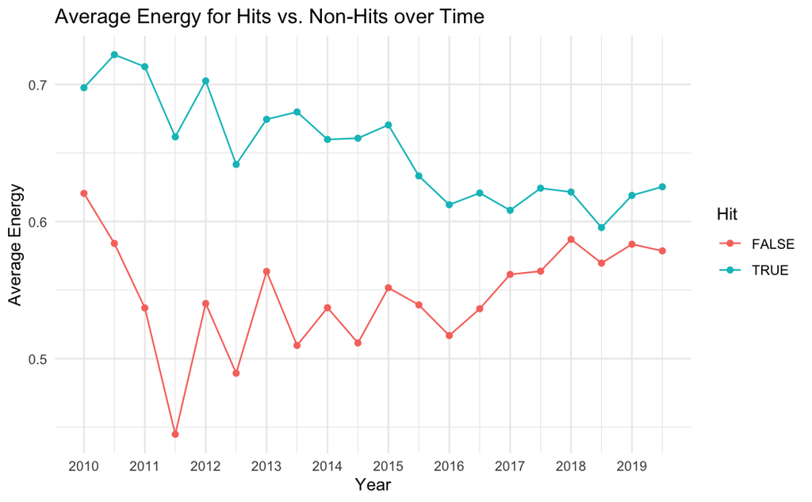

**Key observation**: Hit songs consistently maintained higher energy levels than non-hits throughout the decade (ranging from 0.60–0.72 for hits vs. 0.43–0.61 for non-hits). The gap between hits and non-hits was most pronounced in the early 2010s and gradually narrowed toward 2019, suggesting that energy became a less distinctive marker of success over time. This preliminary finding aligns well with our first hypothesis that energy is a positive predictor of chart success.

#### Valence Over Time

Valence—Spotify’s measure of musical positiveness or cheerfulness—also showed interesting trends:

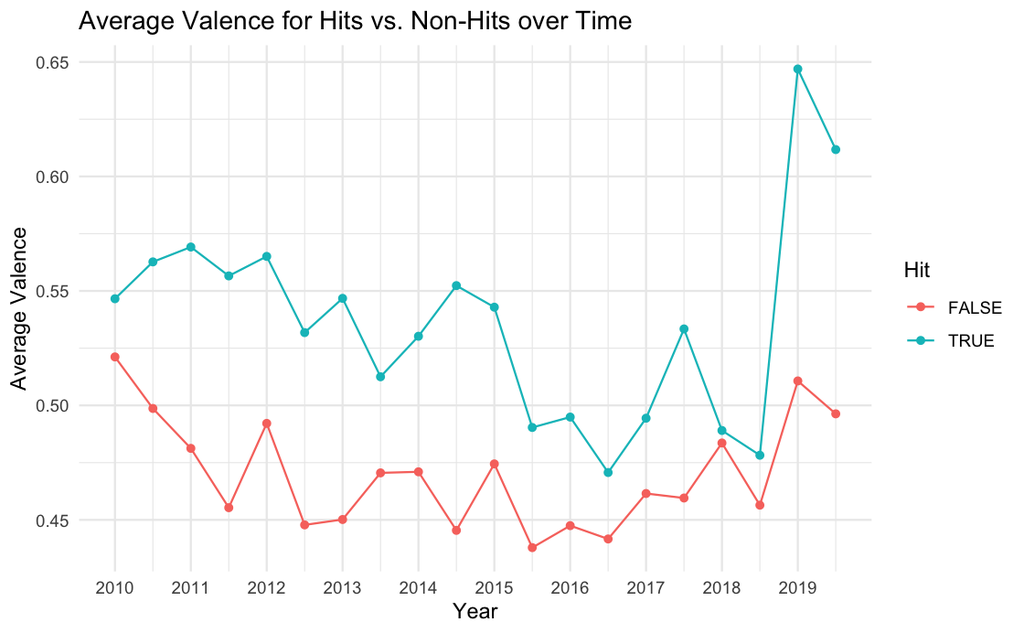

#### Danceability Over Time

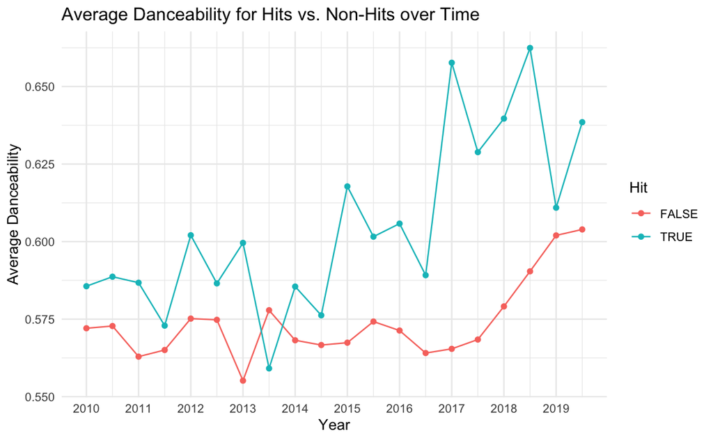

#### Acousticness Over Time

In contrast, acousticness—the presence of acoustic versus electronic production—showed the clearest inverse relationship with hit status:

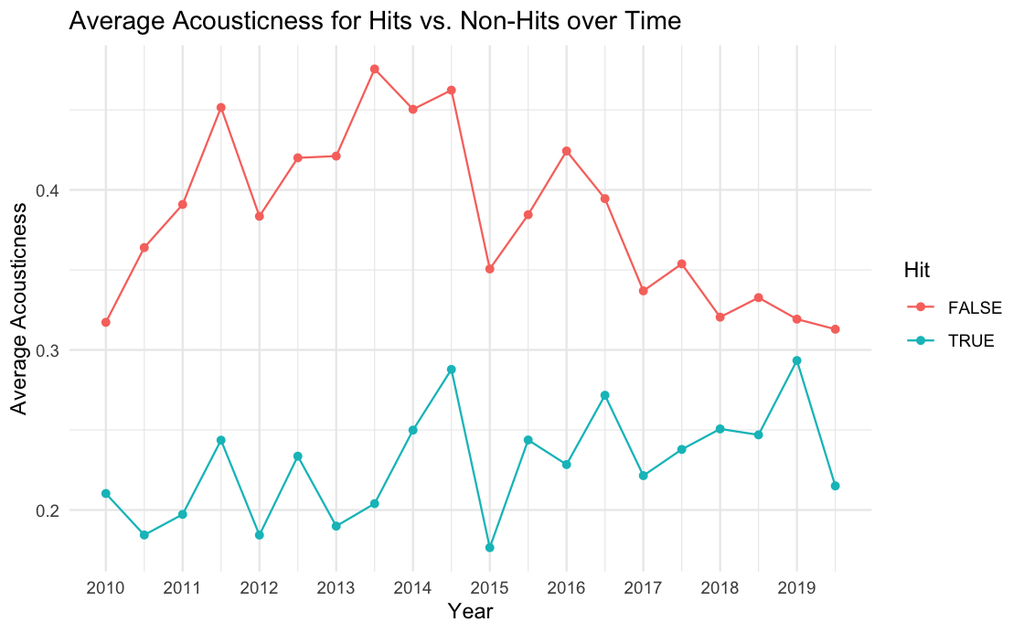

Non-hit songs had substantially higher acousticness levels (0.30–0.48) compared to hits (0.17–0.30). This difference suggests that acousticness is one of the strongest differentiators in our data. Songs that charted tended to be more produced and electronic, while more acoustic, folk-influenced, or singer-songwriter tracks rarely achieved mainstream success. This finding strongly validates our hypothesis that lower acousticness is associated with commercial success.

### Correlation Analysis

To understand how our audio features relate to one another and to hit status, we computed a correlation matrix of all numerical variables:

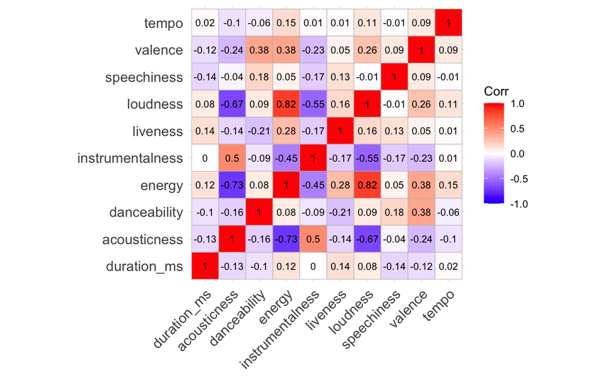

Several notable correlations emerge from this analysis:

- **Energy and Loudness** (r = 0.82): These features are highly correlated, which makes intuitive sense—louder songs tend to be more energetic.
- **Acousticness and Energy** (r = -0.73): A strong negative correlation confirms that acoustic songs tend to be quieter and less energetic.
- **Acousticness and Loudness** (r = -0.67): As expected from the above, acoustic songs tend to be quieter.
- **Acousticness and Instrumentalness** (r = 0.50): Songs with higher acousticness tend to have a high instrumentalness rather than vocals.

-**Valence and Danceability/Energy** (r = 0.38): A slightly weaker correlation demonstrates that happier songs tend to have slightly higher levels of danceability and energy.

These correlations suggest potential **multicollinearity** issues in our data—some features are redundant predictors of a similar musical idea. This will be important to consider when building our models, as highly correlated predictors can increase variance and make it difficult to tell which predictors actually matter.

### Summary of EDA Findings

Our exploratory analysis provides strong preliminary support for our initial hypotheses:

1. Energy, danceability, and valence tend to be higher in hit songs
2. Acousticness tends to be lower in hit songs
3. Hit rates vary dramatically by genre, indicating that commercial success is partly driven by the music category itself. We will determine/see exactly to what extent after we run our models!
4. All features showed year-to-year fluctuations (e.g. energy levels between hits/nonhits seem to be converging), suggesting that the expectations for a hit may shift over time.
5. The correlation map suggests possible multicollinearity issues, which we’ll address during the modeling phase through model and feature selection.

Next, we will get into our **Methodology** process, including our modeling choices.